# Classifying whether twitter author spreads hate using supervised learning

#### *Team members*

| Name | Email-Id | Mattr No. |
| --- | --- | --- |
| Anish Kumar Singh | anish.singh@st.ovgu.de | 234934 |
| Priyanka Singh | priyanka.singh@st.ovgu.de | 235252 |
| Ramanpreet Kaur | ramanpr1@st.ovgu.de | 230367 |
| Venkata Srinath Mannam | venkata.mannam@st.ovgu.de | 229750 |

## Background and motivation

Around the world, we are seeing an unsettling groundswell of racism, xenophobia, and intolerance – including rising anti-Semitism, anti-Muslim hatred, and persecution of Christians. Many forms of communication including Social media are being exploited as platforms for spreading hate, which unfortunately later leads to acts of discrimination and violence. Popular belief and prevailing sentiments among the public majority are being amplified for political gain which targets minorities, women, migrants, refugees and thus leading to human rights violations in any form. Hate speech is a danger to social stability, democratic values, peace.

The term hate speech is understood as any kind of communication in speech, writing or behavior, that attacks or uses pejorative or discriminatory language concerning a person or a group based on who they are, in other words, based on their religion, ethnicity, nationality, race, color, descent, gender or another identity factor. This is often rooted in, and generates intolerance and hatred and, in certain contexts, can be demeaning and divisive

Due to emergence of social media there has been increasing incidences of hate speech around the world on different subjects such as race, religion, gender,etc. Huge amount of data is generated on social media and it becomes important to detect the problem of hate speech to fight against misogyny and xenophobia. In the end we want to identify possible hate speech spreader on Twitter and restrict them, this can act as first step to stop hate speech from spreading in a community among online users and analyzing possible keywords that helpful in detecting hateful tweets.

## Project objectives

1. Classification of twitter users whether the user spread hate or not (binary classification)
2. Unsupervised keyword extraction from tweets to get target topics using NLP tools for classifying the stance of tweets towards a target topic.
3. Analyzing keywords useful for hate speech detection.
4. Comparison of different classifier (Naïve Bayes, Decision Trees, Logistic Regression)
5. Visualizing insights after classification.

## Dataset

The source dataset for our project is from PAN dataset. The dataset which we are using is from an ongoing competition by professor of Polytechnic University of Valencia. The datasource for our project are XML files for 500 Twitter authors. There is one XML file per author and there are around 200 tweets in each file. For training set we have data for 300 authors and for test set it’s about 200 authors.

https://pan.webis.de/clef21/pan21-web/author-profiling.html

## Design overview

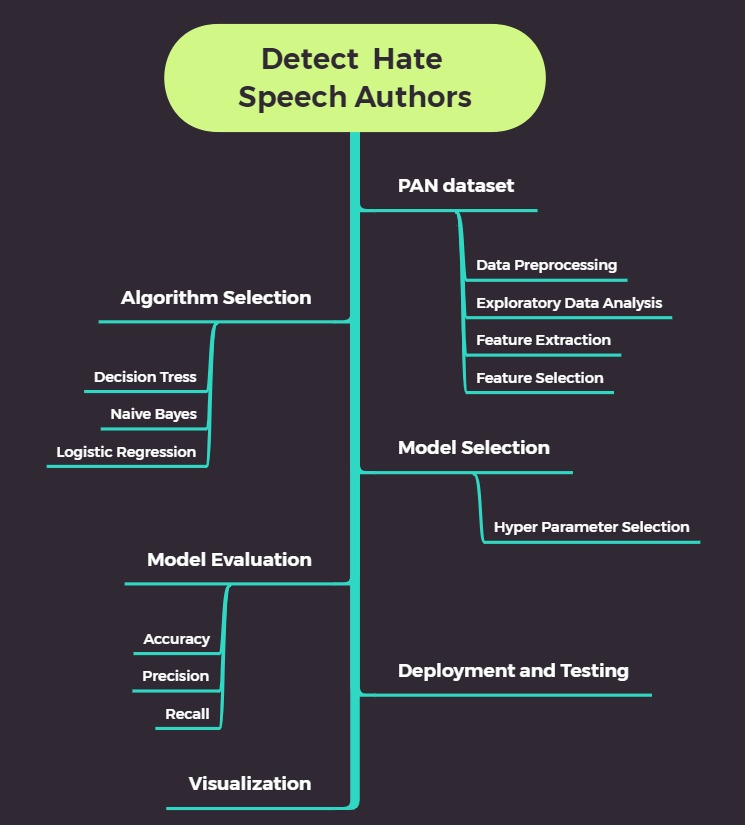

## Project Timeline and Responsibilities

| Task Description | Deadline | **People Responsible** | Reviewed by |
| --- | --- | --- | --- |
| Data Pre-processing and structuring | 29.05.2021 | Priyanka, Raman | Anish, Srinath |
| Feature Extraction | 05.06.2021 | Anish, Srinath | Priyanka, Raman |
| Exploratory Data Analysis and Visualization | 12.06.2021 | Priyanka, Srinath | Anish,Raman |
| Model selection and Hyperparameters tuning | 19.06.2021 | Anish, Priyanka, Raman | Srinath |
| Predictive Modelling and Model Evaluation | 26.06.2021 | All | All |
| Adhoc issues and Testing | 29.06.2021 | All |  |
| Visualization and Website Content | 03.07.2021 | All |  |

## Github and Related Links

https://github.com/anish-singh-07/DataSciR http://personales.upv.es/prosso/resources/BasileEtAl_SemEval19.pdf